# Regresja

- Pokaż cały kod
- Ukryj cały kod
- Pokaż źródło

Autor

Sebastian

Utworzono

24 sierpnia 2026

### 1. Załaduj potrzebne pakiety

**Kod**

```r
library(ISLR2)
library(skimr)
library(tidyverse)
library(rpart)
library(rpart.plot)
library(tidymodels)
library(ranger)
library(future)
library(doFuture)
```

### 2. Regresja

> Będziesz potrzebować zbioru danych `Carseats` z pakietu `ISLR2`.

##### (a) Zapoznaj się ze zbiorem `Carseats` (zobacz jego strukturę (`skimr`), opis zmiennych, a następnie wyświetl dane).

**Kod**

```r
skim(Carseats)
```

Data summary

| Name | Carseats |
| --- | --- |
| Number of rows | 400 |
| Number of columns | 11 |
| _______________________ |  |
| Column type frequency: |  |
| factor | 3 |
| numeric | 8 |
| ________________________ |  |
| Group variables | None |

**Variable type: factor**

| skim_variable | n_missing | complete_rate | ordered | n_unique | top_counts |
| --- | --- | --- | --- | --- | --- |
| ShelveLoc | 0 | 1 | FALSE | 3 | Med: 219, Bad: 96, Goo: 85 |
| Urban | 0 | 1 | FALSE | 2 | Yes: 282, No: 118 |
| US | 0 | 1 | FALSE | 2 | Yes: 258, No: 142 |

**Variable type: numeric**

| skim_variable | n_missing | complete_rate | mean | sd | p0 | p25 | p50 | p75 | p100 | hist |
| --- | --- | --- | --- | --- | --- | --- | --- | --- | --- | --- |
| Sales | 0 | 1 | 7.50 | 2.82 | 0 | 5.39 | 7.49 | 9.32 | 16.27 | ▁▆▇▃▁ |
| CompPrice | 0 | 1 | 124.97 | 15.33 | 77 | 115.00 | 125.00 | 135.00 | 175.00 | ▁▅▇▃▁ |
| Income | 0 | 1 | 68.66 | 27.99 | 21 | 42.75 | 69.00 | 91.00 | 120.00 | ▇▆▇▆▅ |
| Advertising | 0 | 1 | 6.64 | 6.65 | 0 | 0.00 | 5.00 | 12.00 | 29.00 | ▇▃▃▁▁ |
| Population | 0 | 1 | 264.84 | 147.38 | 10 | 139.00 | 272.00 | 398.50 | 509.00 | ▇▇▇▇▇ |
| Price | 0 | 1 | 115.80 | 23.68 | 24 | 100.00 | 117.00 | 131.00 | 191.00 | ▁▂▇▆▁ |
| Age | 0 | 1 | 53.32 | 16.20 | 25 | 39.75 | 54.50 | 66.00 | 80.00 | ▇▆▇▇▇ |
| Education | 0 | 1 | 13.90 | 2.62 | 10 | 12.00 | 14.00 | 16.00 | 18.00 | ▇▇▃▇▇ |

**Kod**

```r
Carseats
```

|  | Sales | CompPrice | Income | Advertising | Population | Price | ShelveLoc | Age | Education | Urban | US |
| --- | --- | --- | --- | --- | --- | --- | --- | --- | --- | --- | --- |
| 1 | 9.50 | 138 | 73 | 11 | 276 | 120 | Bad | 42 | 17 | Yes | Yes |
| 2 | 11.22 | 111 | 48 | 16 | 260 | 83 | Good | 65 | 10 | Yes | Yes |
| 3 | 10.06 | 113 | 35 | 10 | 269 | 80 | Medium | 59 | 12 | Yes | Yes |
| 4 | 7.40 | 117 | 100 | 4 | 466 | 97 | Medium | 55 | 14 | Yes | Yes |
| 5 | 4.15 | 141 | 64 | 3 | 340 | 128 | Bad | 38 | 13 | Yes | No |
| 6 | 10.81 | 124 | 113 | 13 | 501 | 72 | Bad | 78 | 16 | No | Yes |
| 7 | 6.63 | 115 | 105 | 0 | 45 | 108 | Medium | 71 | 15 | Yes | No |
| 8 | 11.85 | 136 | 81 | 15 | 425 | 120 | Good | 67 | 10 | Yes | Yes |
| 9 | 6.54 | 132 | 110 | 0 | 108 | 124 | Medium | 76 | 10 | No | No |
| 10 | 4.69 | 132 | 113 | 0 | 131 | 124 | Medium | 76 | 17 | No | Yes |

[output cut: 390 more lines]

**Kod**

```r
help("Carseats")
```

##### (b) Co oznacza zmienna `ShelveLoc`?

- **Twoja odpowiedź:** Zmienna `ShelveLoc` to zmienna o trzech poziomach: `Bad`, `Medium`, `Good`. Określa ona jakość lokalizacji fotelika samochodowego na półce w sklepie.

#### 2a. Regresja liniowa

##### Przy użyciu `ggplot` wykonaj wykres rozrzutu: `Sales` vs `Price` (uważaj na to, jak należy zinterpretować ten zapis na wykresie, tzn. co jest zmienną $x$ a co $y$ ). Używając różnych kolorów dopasuj regresję liniową, kwadratową i sześcienną (na jednym wykresie z odpowiednią legendą informującą która krzywa określa który stopień; nie rysuj przedziału ufności).

**Kod**

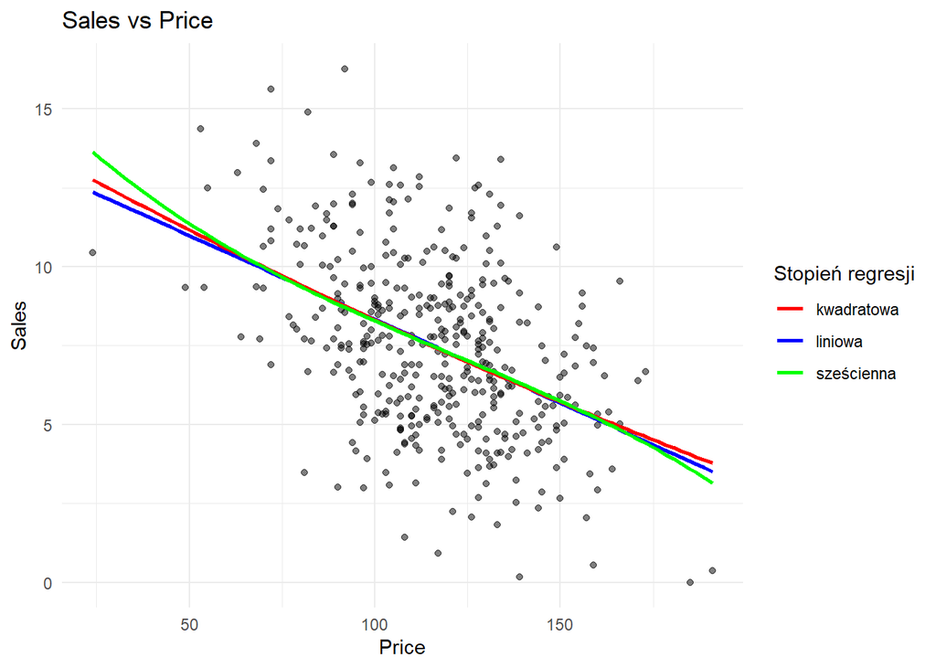

```r
ggplot(Carseats, aes(x = Price, y = Sales)) +
  geom_point(alpha = 0.5) +
  geom_smooth(aes(color = "liniowa"),
              method = "lm", formula = y ~ x, se = FALSE) +
  geom_smooth(aes(color = "kwadratowa"),
              method = "lm", formula = y ~ poly(x, 2), se = FALSE) +
  geom_smooth(aes(color = "sześcienna"),
              method = "lm", formula = y ~ poly(x, 3), se = FALSE) +
  scale_color_manual(
    name = "Stopień regresji",
    values = c("liniowa" = "blue",
               "kwadratowa" = "red",
               "sześcienna" = "green")
  ) +
  labs(title = "Sales vs Price", x = "Price", y = "Sales") +
  theme_minimal()
```

##### Stwórz model regresji liniowej wykorzystując zmienną `ShelveLoc` i 6 innych losowo wybranych zmiennych, odzwierciedlający wpływ wszystkich tych zmiennych na zmienną `Sales` (do losowania tych zmiennych za ziarno losowania przyjmij **numer swojego indeksu**). Nazwij go `model_lm`. Zobacz podsumowanie modelu i odczytaj współczynnik $R^2$.

**Kod**

```r
set.seed(345777)

zmienne_dostepne <- setdiff(names(Carseats), c("Sales", "ShelveLoc"))

losowe_zmienne <- sample(zmienne_dostepne, 6)
losowe_zmienne
```

```
[1] "Advertising" "US"          "CompPrice"   "Price"       "Urban"
[6] "Population"
```

**Kod**

```r
predyktory <- c("ShelveLoc", losowe_zmienne)
formula_lm <- as.formula(
  paste("Sales ~", paste(predyktory, collapse = " + "))
)
formula_lm
```

```
Sales ~ ShelveLoc + Advertising + US + CompPrice + Price + Urban +
    Population
```

**Kod**

```r
model_lm <- lm(formula_lm, data = Carseats)
summary(model_lm)
```

```
Call:
lm(formula = formula_lm, data = Carseats)

Residuals:
    Min      1Q  Median      3Q     Max
-3.8001 -0.8872 -0.0083  0.8980  4.4905

Coefficients:
                  Estimate Std. Error t value Pr(>|t|)
(Intercept)      3.6812584  0.5980715   6.155 1.86e-09 ***
ShelveLocGood    4.7475245  0.2010257  23.617  < 2e-16 ***
ShelveLocMedium  1.7823876  0.1652366  10.787  < 2e-16 ***
Advertising      0.1237120  0.0146027   8.472 4.96e-16 ***
USYes           -0.1248634  0.1958706  -0.637    0.524
CompPrice        0.0941021  0.0054374  17.307  < 2e-16 ***
Price           -0.0936961  0.0035087 -26.704  < 2e-16 ***
UrbanYes         0.0996055  0.1483312   0.672    0.502
Population       0.0004115  0.0004834   0.851    0.395
---
Signif. codes:  0 '***' 0.001 '**' 0.01 '*' 0.05 '.' 0.1 ' ' 1

Residual standard error: 1.341 on 391 degrees of freedom
Multiple R-squared:  0.7792,    Adjusted R-squared:  0.7747
F-statistic: 172.5 on 8 and 391 DF,  p-value: < 2.2e-16
```

**Kod**

```r
summary(model_lm)$r.squared
```

```
[1] 0.7792082
```

- **Uzupełnij:**
  $$R^2 = 0.7792082$$

##### Co oznacza współczynnik przy `ShelveLocGood`? Jak należy go zinterpretować (pamiętaj o jednostkach sprzedaży)? Co możesz powiedzieć o istotności statystycznej tej zmiennej w Twoim modelu?

- **Twoja odpowiedź:** Poziomem odniesienia dla zmiennej `ShelveLoc` jest `Bad`, dlatego w modelu pojawiają się współczynniki `ShelveLocGood` oraz `ShelveLocMedium`. Współczynnik przy `ShelveLocGood` oznacza, że przejście z lokalizacji `Bad` na `Good` zwiększa przewidywaną sprzedaż średnio o 4700 jednostek. Patrząc na p-wartość zmienna ta jest wysoce istotna statystycznie jej wpływ na sprzedaż jest zatem statystycznie istotny.

#### 2b. Drzewo regresyjne

##### Biorąc pod uwagę te same zmienne co w modelu regresji liniowej, przy użyciu pakietu `rpart` najpierw utwórz model regresji o nazwie `drzewo` , a następnie narysuj je (używając odpowiedniego pakietu).

**Kod**

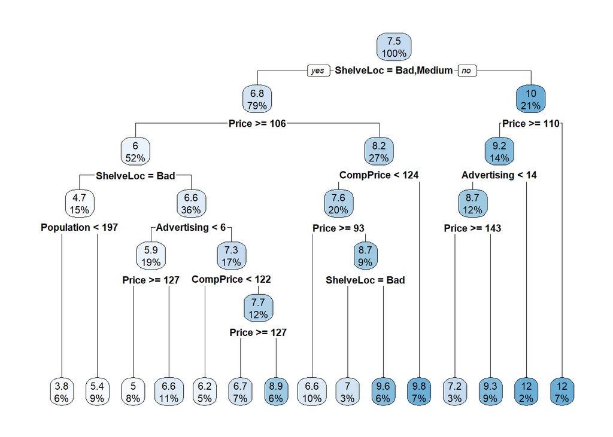

```r
drzewo <- rpart(formula_lm, data = Carseats)

rpart.plot(drzewo)
```

##### Czy któreś ze zmiennych **nie** zostały uznane za ważne w procesie tworzenia drzewa? Jeśli tak, to które?

- **Twoja odpowiedź:** Zmienne `US`, `Urban` nie zostaly uznane za wazne

##### Ile (dokładnie) obserwacji wpadło do węzła nr 13. Czy to jest liść? Jeśli w Twoim drzewie nie ma węzła o tym numerze, to weź pod uwagę najbliższy nieparzysty numer węzła.

- **Twoja odpowiedź:** Ma on dokładnie 9 obserwacji. Jest to liść

##### Udałeś/udałaś się na spotkanie z klientem. Nie zabrałeś komputera, ale jako miłośnik przyrody, rysunki drzew zawsze nosisz przy sobie :) Klient nalega na prognozę sprzedaży w przypadku: `Urban = Yes`, `Population = 200`, `Income = 60`, `Advertising = 7`, `Age = 40`, `CompPrice = 120`, `ShelveLoc = Medium`, `US = No`, `Price = 105`, `Education = 11`. Patrząc na swoje drzewo prognozuj sprzedaż. Pamiętaj o odpowiedniej jednostce.

- **Twoja odpowiedź:** 6.600 jednostek

#### 2c. Random Forest + trening hiperparametrów

##### Z wykorzystaniem pakietu `tidymodels` wykonaj trening hiperparametrów dla modelu lasów losowych z uwzględnieniem następujących kroków:

- wszystkie losowe procedury wykonaj z ustawieniem swojego wcześniejszego ziarna losowania
- cała procedura powinna wykorzystywać odpowiednie funkcje z pakietu `tidymodels`
- pamiętaj, że możesz “zamrozić” dany chunk, żeby przy każdorazowym renderowaniu dokumentu nie przeliczał na nowo wszystkiego co tam jest zawarte i żeby mieć pewność, że komentowane przez Ciebie treści i podsumowania są właściwe
- do tworzenia modelu wykorzystaj wszystkie zmienne (nadal przewidujesz `Sales`)
- podziel dane na zbiór treningowy i testowy (prop = 0.8), trening hiperparametrów zrób z wykorzystaniem kroswalidacji na zbiorze treningowym
- użyj modelu z “silnikiem” `ranger`
- trenowane 2 hiperparametry: liczba drzew i liczba zmiennych losowanych do podziału w każdym węźle (reszta parametrów - domyślna)
- w siatce hiperparametrów do treningu wykorzystaj wartości:
  - liczba drzew: 100, 500, 1000,
  - liczba zmiennych losowanych do podziału: 3, 4, 5
  - w systemie: “każdy z każdym”, tzn. 9 różnych modeli
- zoptymalizuj czas treningu przy użyciu pakietu do obliczeń równoległych (future, doFuture)
- wyświetl wyniki dla wszystkich modeli z informacją o otrzymanych wartościach: RMSE, MAE i $R^2$ (wszystko w jednej tabelce)
- przy użyciu odpowiedniej funkcji z pakietu `tidymodels` wyświetl 4 modele z najlepszą wartością RMSE (jakie parametry okazały się najlepsze?)
- dokończ budowę tego najlepszego modelu, a następnie sprawdź jakie wartości wszystkich 3 metryk przyjmuje ten model na zbiorze testowym. Odpowiedz na pytanie, jak te wartości wypadają w porównaniu do wcześniejszych kroswalidacyjnych prognoz.

**Kod**

```r
set.seed(345777)

podzial <- initial_split(Carseats, prop = 0.8)
train   <- training(podzial)
test    <- testing(podzial)

folds <- vfold_cv(train)

przepis <- recipe(Sales ~ ., data = train)

spec_rf <- rand_forest(
    trees = tune(),
    mtry  = tune()
  ) %>%
  set_engine("ranger") %>%
  set_mode("regression")

wf <- workflow() %>%
  add_recipe(przepis) %>%
  add_model(spec_rf)

siatka <- crossing(
  trees = c(100, 500, 1000),
  mtry  = c(3, 4, 5)
)

metryki <- metric_set(rmse, mae, rsq)
```

**Kod**

```r
registerDoFuture()
plan(multisession)

set.seed(345777)
wyniki_tune <- tune_grid(
  wf,
  resamples = folds,
  grid      = siatka,
  metrics   = metryki
)

plan(sequential)
```

**Kod**

```r
wyniki_tabela <- collect_metrics(wyniki_tune) %>%
  select(trees, mtry, .metric, mean) %>%
  pivot_wider(names_from = .metric, values_from = mean) %>%
  arrange(rmse)

wyniki_tabela
```

| trees | mtry | mae | rmse | rsq |
| --- | --- | --- | --- | --- |
| 500 | 5 | 1.375514 | 1.702010 | 0.6520732 |
| 1000 | 5 | 1.373613 | 1.703885 | 0.6508062 |
| 100 | 5 | 1.371255 | 1.709888 | 0.6458658 |
| 100 | 4 | 1.388495 | 1.724467 | 0.6532263 |
| 500 | 4 | 1.400136 | 1.736595 | 0.6518464 |
| 1000 | 4 | 1.402848 | 1.739740 | 0.6477486 |
| 1000 | 3 | 1.452458 | 1.804927 | 0.6342141 |
| 500 | 3 | 1.455085 | 1.808454 | 0.6306281 |
| 100 | 3 | 1.464636 | 1.816479 | 0.6196906 |

**Kod**

```r
najlepsze <- show_best(wyniki_tune, metric = "rmse", n = 4)
najlepsze
```

| mtry | trees | .metric | .estimator | mean | n | std_err | .config |
| --- | --- | --- | --- | --- | --- | --- | --- |
| 5 | 500 | rmse | standard | 1.702010 | 10 | 0.06284526 | pre0_mod8_post0 |
| 5 | 1000 | rmse | standard | 1.703885 | 10 | 0.05929948 | pre0_mod9_post0 |
| 5 | 100 | rmse | standard | 1.709888 | 10 | 0.05943673 | pre0_mod7_post0 |
| 4 | 100 | rmse | standard | 1.724467 | 10 | 0.06909450 | pre0_mod4_post0 |

**Kod**

```r
best_params <- select_best(wyniki_tune, metric = "rmse")
best_params
```

| mtry | trees | .config |
| --- | --- | --- |
| 5 | 500 | pre0_mod8_post0 |

**Kod**

```r
wf_final <- finalize_workflow(wf, best_params)

set.seed(345777)
final_fit <- last_fit(wf_final, split = podzial, metrics = metryki)

collect_metrics(final_fit)
```

| .metric | .estimator | .estimate | .config |
| --- | --- | --- | --- |
| rmse | standard | 1.6851008 | pre0_mod0_post0 |
| mae | standard | 1.2738513 | pre0_mod0_post0 |
| rsq | standard | 0.8225012 | pre0_mod0_post0 |

- **Twoja odpowiedź (porównanie):** Lepszy na testowym, model dobrze uogólnia.